# Tweedie likelihood computations

## Tweedie distributions

Tweedie distributions are exponential dispersion models, with a mean $\mu$ and a variance $\phi \mu^\xi$, for some dispersion parameter $\phi > 0$ and a variance-power index $\xi$ (Tweedie 1984), that is sometimes called $p$, that uniquely defines the distribution within the Tweedie family (for all real values of $\xi$ **not** between 0 and 1).

Special cases of the Tweedie distributions are:

- the *normal* distribution, with $\xi = 0$ (i.e., the variance is $\phi$ and not related to the mean);
- the *Poisson* distribution, with $\xi = 1$ and $\phi = 1$ (i.e., the variance is the same as the mean);
- the *gamma* distribution, with $\xi = 2$; and
- the *inverse Gaussian* distribution, with $\xi = 3$.

For all other values of $\xi$, the probability functions and distribution functions have no closed forms.

| Variance power, $\xi$ | Distribution | Support |
| --- | --- | --- |
| $\xi = 0$ | Normal | $(-\infty, \infty)$ |
| $0 < \xi < 1$ | Do not exist |  |
| $\xi = 1$ (with $\phi = 1)$ | Poisson | Discrete: $(0, 1, 2, \dots)$ |
| $1 < \xi < 2$ | Poisson–gamma | $[ 0, \infty)$ |
| $\xi = 2$ | Gamma | $(0, \infty)$ |
| $\xi > 2$ | Skewed right | $(0, \infty$) |
| $\xi = 3$ | inverse Gaussian | $(0, \infty)$ |

For $1 < \xi < 2$, Tweedie distributions can be represented as a Poisson sum of gamma distributions. These distributions are continuous for $Y > 0$ but have a discrete mass at $Y = 0$.

## Use cases

Likelihood computations are not need to fit a Tweedie generalized linear model, using the `tweedie()` family from the [**statmod** package](https://CRAN.R-project.org/package=statmod) (Smyth et al. (2025), Dunn and Smyth (2018)):

```r
library(tweedie)
library(statmod)   # For the tweedie() family function, for use in glm()

set.seed(96)
N <- 25
# Mean of the Poisson (lambda) and Gamma (shape/scale)
lambda <- 1.5
# Generating Compound Poisson-Gamma data manually
y <- replicate(N, {
  n_events <- rpois(1, lambda = lambda)
  if (n_events == 0) 0 else sum(rgamma(n_events, shape = 2, scale = 1))
})

mod.tw <- glm(y ~ 1,
              family = statmod::tweedie(var.power = 1.5, link.power = 0) )
              # link.power = 0  means the log-link
```

However, likelihood computations are necessary in other situations. Since likelihoods cannot be computed analytically apart from special cases, the **tweedie** package computes Tweedie densities using numerical methods (Dunn and Smyth (2005), Dunn and Smyth (2008)).

### Generating random numbers

Random numbers from a Tweedie distribution are generated using **rtweedie()**:

```r
tweedie::rtweedie(10, xi = 1.1, mu = 2, phi = 1)
```

```
#>  [1] 1.536587 2.520597 4.624115 1.999447 2.532301 4.259932 1.725366 0.000000
#>  [9] 0.000000 2.545023
```

### Plotting density and probability functions

Accurate density functions are generated using **dtweedie()**:

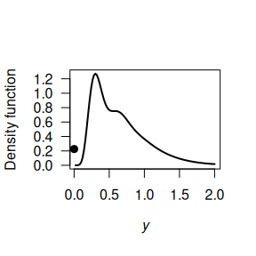

```r
y <- seq(0, 2, length = 100)
xi <- 1.1
mu <- 0.5
phi <- 0.4

twden <- tweedie::dtweedie(y, xi = xi, mu = mu, phi = phi)
twdtn <- tweedie::ptweedie(y, xi = xi, mu = mu, phi = phi)

plot( twden[y > 0] ~ y[y > 0],
      xlab = expression(italic(y)),
      ylab = "Density function",
      type ="l",
      lwd = 2,
      las = 1)
points(twden[y==0] ~ y[y == 0],
      lwd = 2,
      pch = 19)
```

Accurate probability functions are generated using **ptweedie()**:

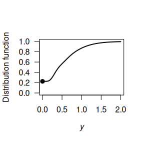

```r
plot(twdtn ~ y,
     xlab = expression(italic(y)),
     ylab = "Distribution function",
     type = "l",
     las = 1,
     lwd = 2,
     las = 1,
     ylim = c(0, 1) )
points(twdtn[y==0] ~ y[y == 0],
      lwd = 2,
      pch = 19)
```

However, the function **tweedie_plot()** is sometimes more convenient (especially for $1 < \xi \ < 2$, when a probability mass at $Y = 0$ is present):

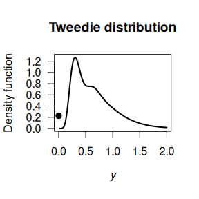

```r
tweedie::tweedie_plot(y, xi = xi, mu = mu, phi = phi,
                      ylab = "Density function",
                      xlab = expression(italic(y)),
                      las = 1,
                      lwd = 2)
```

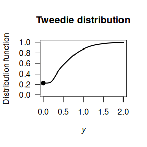

```r
tweedie::tweedie_plot(y, xi = xi, mu = mu, phi = phi,
                      ylab = "Distribution function",
                      xlab = expression(italic(y)),
                      las = 1,
                      lwd = 2,
                      ylim = c(0, 1),
                      type = "cdf")
```

### Computing the quantile residuals

Quantile residuals (Dunn and Smyth 1996) can be computed to assess the fit of a glm. The function **qresid()** is in the [**statmod** package](https://CRAN.R-project.org/package=statmod) (Smyth et al. (2025), Dunn and Smyth (2018)):

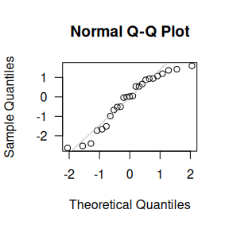

```r
library(tweedie)

qqnorm( qr <- statmod::qresid(mod.tw),
        las = 1)
qqline(qr,
       col = "grey")
```

### Estimating $\xi$

To use a Tweedie distribution in a glm, the value of $\xi$ is needed. To find the most suitable value of $\xi$, **tweedie_profile()** can be used (Dunn and Smyth 2018):

[output not shown]

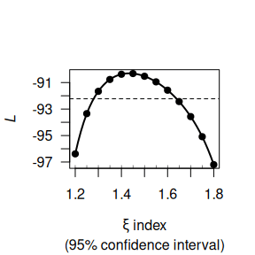

```r
out <- tweedie::tweedie_profile(y ~ 1,
                                xi.vec = seq(1.2, 1.8, by = 0.05),
                                do.plot = TRUE)
```

```r
# The estimated power index:
out$xi.max
```

```
#> [1] 1.432653
```

## Example

Consider the `poison` data in the `GLMsData` package (Dunn and Smyth 2022), which records the survival times of animals under various treatments and poisons (used in Dunn and Smyth (2018), Sect. 12.4.2). For convenience, a copy is included with this package:

```r
poison <- read.csv(system.file("extdata", "poison.csv", package = "tweedie"))

# Convert to factors:
poison$Psn <- factor(poison$Psn)
poison$Trmt <- factor(poison$Trmt)

head(poison)
```

```
#>   Psn Trmt Time
#> 1   I    A 0.31
#> 2   I    A 0.45
#> 3   I    A 0.46
#> 4   I    A 0.43
#> 5   I    B 0.82
#> 6   I    B 1.10
```

The survival time is likely related to the poison type and type of treatment:

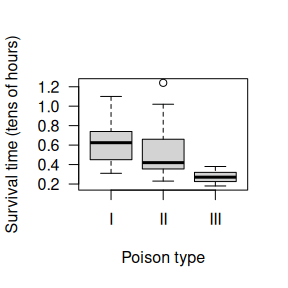

```r
plot(Time ~ Psn,
     data = poison,
     xlab = "Poison type",
     ylab = "Survival time (tens of hours)",
     las = 1)
```

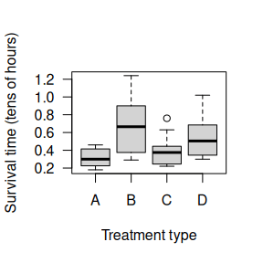

```r
plot(Time ~ Trmt,
     data = poison,
     xlab = "Treatment type",
     ylab = "Survival time (tens of hours)",
     las = 1)
```

In both cases, the variance of the survival times seems to increase with the mean survival time. Perhaps a Tweedie glm would be appropriate. To fit a Tweedie glm, the value of $\xi$ is needed; since no exact zeros are present (or possible) for the survival times, very likely $\xi \ge 2$:

[output not shown]

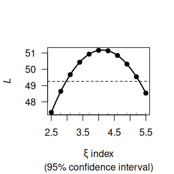

```r
PSNPrf <- tweedie_profile(Time ~ Trmt + Psn, data = poison,
                          do.plot = TRUE, xi.vec = seq(2.5, 5.5, length = 11) )
```

Then, $\xi\approx 4$:

```r
PSNPrf$xi.max
```

```
#> [1] 4.091837
```

So then the Tweedie glm can be fitted:

```r
PSNMod <- glm(Time ~ Trmt + Psn,
              data = poison,
              family=statmod::tweedie(var = 4, link.power = 0))
anova(PSNMod, test = "F")
```

[output not shown]

Quantile residuals can be used to assess the model:

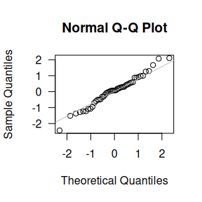

```r
qr <- statmod::qresid(PSNMod)
qqnorm(qr,
       las = 1)
qqline(qr,
       col = "grey")
```

The quantile residuals suggest that this model looks fine.

## References

Dunn, Peter K., and Gordon K. Smyth. 1996. “Randomized Quantile Residuals.” *Journal of Computational and Graphical Statistics* 5 (3): 236–44.

———. 2005. “Series Evaluation of Tweedie Exponential Dispersion Model Densities.” *Statistics and Computing* 15 (4): 267–80.

———. 2008. “Evaluation of Tweedie Exponential Dispersion Model Densities by Fourier Inversion.” *Statistics and Computing* 18 (1): 73–86.

———. 2018. *Generalized Linear Models with Examples in R*. Springer.

———. 2022. *GLMsData: Generalized Linear Model Data Sets*. https://doi.org/10.32614/CRAN.package.GLMsData.

Smyth, Gordon K., Lizhong Chen, Yifang Hu, Peter K. Dunn, Belinda Phipson, and Yunshun Chen. 2025. “Statmod: Statistical Modeling.”

Tweedie, M. C. K. 1984. “An Index Which Distinguishes Between Some Important Exponential Families.” *Statistics: Applications and New Directions*, 579–604.